# Programming with Python

## Basic data processing and analysis using python libraries: NumpPy

#### Asst. Prof Roshan Tandukar

### NumPy

It is the fundamental package for scientific computing in Python.

NumPy, short for Numerical Python, is one of the most important foundational pack‐ ages for numerical computing in Python.

Many computational packages providing scientific functionality use NumPy’s array objects as one of the standard interface for data exchange.

### NumPy

It provides a multidimensional array object, various derived objects (such as masked arrays and matrices), and an assortment of routines for fast operations on arrays, including mathematical, logical, shape manipulation, sorting, selecting, I/O, discrete Fourier transforms, basic linear algebra, basic statistical operations, random simulation and much more.

At the core of the NumPy package, is the ndarray object.

This encapsulates n-dimensional arrays of homogeneous data types, with many operations being performed in compiled code for performance.

### NumPy

There are several important differences between NumPy arrays and the standard Python sequences:

1. NumPy arrays have a fixed size at creation, unlike Python lists (which can grow dynamically). Changing the size of an ndarray will create a new array and delete the original.
2. The elements in a NumPy array are all required to be of the same data type, and thus will be the same size in memory.
3. NumPy arrays facilitate advanced mathematical and other types of operations on large numbers of data. Typically, such operations are executed more efficiently and with less code than is possible using Python’s built-in sequences.

### Some features of NumPy

ndarray, an efficient multidimensional array providing fast array-oriented arithmetic operations and flexible broadcasting capabilities

Mathematical functions for fast operations on entire arrays of data without having to write loops

Tools for reading/writing array data to disk and working with memory-mapped files

Linear algebra, random number generation, and Fourier transform capabilities

A C API for connecting NumPy with libraries written in C, C++, or FORTRAN

One of the reasons NumPy is so important for numerical computations in Python is because it is designed for efficiency on large arrays of data.  
There are a number of reasons for this:

1. NumPy internally stores data in a contiguous block of memory, independent of other built-in Python objects. NumPy’s library of algorithms written in the C lan‐ guage can operate on this memory without any type checking or other overhead. NumPy arrays also use much less memory than built-in Python sequences
2. NumPy operations perform complex computations on entire arrays without the need for Python for loops, which can be slow for large sequences. NumPy is faster than regular Python code because its C-based algorithms avoid overhead present with regular interpreted Python code.

```python
import numpy as np
```

```python
data = np.array([[1.5, -0.1, 3], [0, -3, 6.5]])
```

```python
data
```

```
array([[ 1.5, -0.1,  3. ],
       [ 0. , -3. ,  6.5]])
```

```python
data+data
```

```
array([[ 3. , -0.2,  6. ],
       [ 0. , -6. , 13. ]])
```

```python
data+2
```

```
array([[ 3.5,  1.9,  5. ],
       [ 2. , -1. ,  8.5]])
```

```python
data*2
```

```
array([[ 3. , -0.2,  6. ],
       [ 0. , -6. , 13. ]])
```

```python
data.shape #dimension of array
```

```
(2, 3)
```

```python
data.dtype #type of the element
```

```
dtype('float64')
```

```python
data.ndim #number of axes or dimensions of the array
```

```
2
```

```python
data.size #total number of elements
```

```
6
```

#### Creating ndarrays

The easiest way to create an array is to use the array function.

This accepts any sequence-like object (including other arrays) and produces a new NumPy array containing the passed data.

```python
 data1 = [6, 7.5, 8, 0, 1]
```

```python
arr1 = np.array(data1)
```

```python
arr1
```

```
array([6. , 7.5, 8. , 0. , 1. ])
```

```python
data2 = [[1, 2, 3, 4], [5, 6, 7, 8]]
```

```python
arr2 = np.array(data2)
```

```python
arr2
```

```
array([[1, 2, 3, 4],
       [5, 6, 7, 8]])
```

```python
arr1.shape
```

```
(5,)
```

```python
arr2.shape
```

```
(2, 4)
```

```python
arr2.ndim
```

```
2
```

```python
arr1.dtype
```

```
dtype('float64')
```

```python
arr2.dtype
```

```
dtype('int32')
```

In addition to numpy.array, there are a number of other functions for creating new arrays.  
Examples:

1. numpy.zeros
2. numpy.ones

```python
np.zeros(10)
```

```
array([0., 0., 0., 0., 0., 0., 0., 0., 0., 0.])
```

```python
# To create a higher dimensional array, pass a tuple for the shape
np.zeros((3,4))
```

```
array([[0., 0., 0., 0.],
       [0., 0., 0., 0.],
       [0., 0., 0., 0.]])
```

```python
np.ones(5)
```

```
array([1., 1., 1., 1., 1.])
```

```python
np.ones((4,2))
```

```
array([[1., 1.],
       [1., 1.],
       [1., 1.],
       [1., 1.]])
```

```python
np.ones((3,2,2))
```

```
array([[[1., 1.],
        [1., 1.]],

       [[1., 1.],
        [1., 1.]],

       [[1., 1.],
        [1., 1.]]])
```

### Shape Manipulation

```python
a=np.arange(10)
a
```

```
array([0, 1, 2, 3, 4, 5, 6, 7, 8, 9])
```

```python
b=np.arange(10).reshape(2,5)
b
```

```
array([[0, 1, 2, 3, 4],
       [5, 6, 7, 8, 9]])
```

```python
c=np.arange(10).reshape(1,5)
```

```
---------------------------------------------------------------------------
ValueError                                Traceback (most recent call last)
Cell In[29], line 1
----> 1 c=np.arange(10).reshape(1,5)

ValueError: cannot reshape array of size 10 into shape (1,5)
```

```python
b.reshape(1,10)
```

```
array([[0, 1, 2, 3, 4, 5, 6, 7, 8, 9]])
```

```python
b.reshape(10,1)
```

```
array([[0],
       [1],
       [2],
       [3],
       [4],
       [5],
       [6],
       [7],
       [8],
       [9]])
```

```python
np.ones_like(b)
```

```
array([[1, 1, 1, 1, 1],
       [1, 1, 1, 1, 1]])
```

```python
np.ones_like(b, float)
```

```
array([[1., 1., 1., 1., 1.],
       [1., 1., 1., 1., 1.]])
```

```python
np.zeros_like(b, float)
```

```
array([[0., 0., 0., 0., 0.],
       [0., 0., 0., 0., 0.]])
```

### Arithmetic with NumPy Arrays

Arrays are important because they enable you to express batch operations on data without writing any for loops.

This is called vectorization.

Any arithmetic operations between equal-size arrays apply the operation element-wise.

```python
arr=np.array(([1,2,3],[3,4,5]))
arr
```

```
array([[1, 2, 3],
       [3, 4, 5]])
```

```python
arr+arr
```

```
array([[ 2,  4,  6],
       [ 6,  8, 10]])
```

```python
arr*arr
```

```
array([[ 1,  4,  9],
       [ 9, 16, 25]])
```

```python
1/arr
```

```
array([[1.        , 0.5       , 0.33333333],
       [0.33333333, 0.25      , 0.2       ]])
```

```python
arr**2
```

```
array([[ 1,  4,  9],
       [ 9, 16, 25]])
```

```python
b
```

```
array([[0, 1, 2, 3, 4],
       [5, 6, 7, 8, 9]])
```

```python
 b1=np.array([[2,3,4,5,6],[3,4,5,6,7]])
b1
```

```
array([[2, 3, 4, 5, 6],
       [3, 4, 5, 6, 7]])
```

```python
b<b1
```

```
array([[ True,  True,  True,  True,  True],
       [False, False, False, False, False]])
```

### Basic Indexing and Slicing

NumPy array indexing is a deep topic, as there are many ways you may want to select a subset of your data or individual elements.

One-dimensional arrays are simple; on the surface they act similarly to Python lists:

```python
arr
```

```
array([[1, 2, 3],
       [3, 4, 5]])
```

```python
arr[1,1]
```

```
4
```

```python
a
```

```
array([0, 1, 2, 3, 4, 5, 6, 7, 8, 9])
```

```python
a[1:3]
```

```
array([1, 2])
```

```python
a[-2]
```

```
8
```

```python
a
```

```
array([0, 1, 2, 3, 4, 5, 6, 7, 8, 9])
```

```python
a[2:-3]
```

```
array([2, 3, 4, 5, 6])
```

```python
a[-4:-1]
```

```
array([6, 7, 8])
```

```python
a[:]
```

```
array([0, 1, 2, 3, 4, 5, 6, 7, 8, 9])
```

```python
a[-2:]
```

```
array([8, 9])
```

```python
a[:-5]
```

```
array([0, 1, 2, 3, 4])
```

```python
b
```

```
array([[0, 1, 2, 3, 4],
       [5, 6, 7, 8, 9]])
```

```python
b[:,:]
```

```
array([[0, 1, 2, 3, 4],
       [5, 6, 7, 8, 9]])
```

```python
b[:,:]
```

```
array([[0, 1, 2, 3, 4],
       [5, 6, 7, 8, 9]])
```

```python
b[:2,:2]
```

```
array([[0, 1],
       [5, 6]])
```

```python
b[1:,:]
```

```
array([[5, 6, 7, 8, 9]])
```

```python
b[1:,1:]
```

```
array([[6, 7, 8, 9]])
```

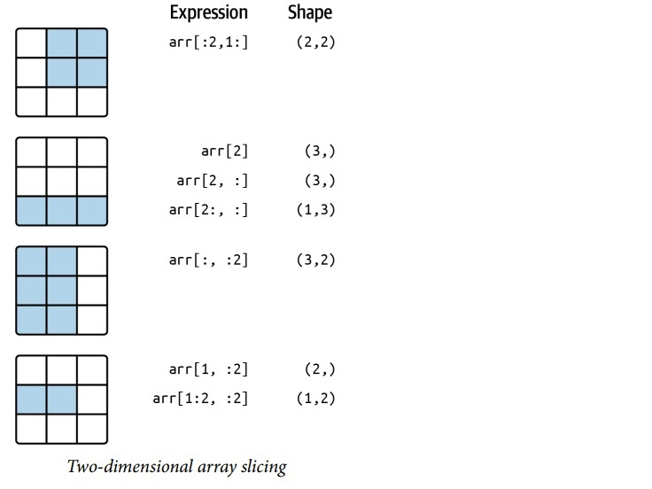

```python
a
```

```
array([0, 1, 2, 3, 4, 5, 6, 7, 8, 9])
```

```python
a[::-1] #Reversing the array
```

```
array([9, 8, 7, 6, 5, 4, 3, 2, 1, 0])
```

```python
a[::2]
```

```
array([0, 2, 4, 6, 8])
```

```python
a[::3]
```

```
array([0, 3, 6, 9])
```

```python
b
```

```
array([[0, 1, 2, 3, 4],
       [5, 6, 7, 8, 9]])
```

```python
b[::-1]
```

```
array([[5, 6, 7, 8, 9],
       [0, 1, 2, 3, 4]])
```

```python
b[::-1,::-1] #b[start:end:incr,start:end:incr]
```

```
array([[9, 8, 7, 6, 5],
       [4, 3, 2, 1, 0]])
```

```python
a==2
```

```
array([False, False,  True, False, False, False, False, False, False,
       False])
```

```python
names=np.array(['ram','sam','sita','ram','gita','sam'])
names
```

```
array(['ram', 'sam', 'sita', 'ram', 'gita', 'sam'], dtype='<U4')
```

```python
names=='ram'
```

```
array([ True, False, False,  True, False, False])
```

```python
names!='ram'
```

```
array([False,  True,  True, False,  True,  True])
```

```python
~(names=='ram')
```

```
array([False,  True,  True, False,  True,  True])
```

```python
names[0]
```

```
'ram'
```

### Fancy Indexing

Fancy indexing is a term adopted by NumPy to describe indexing using integer arrays.

```python
non=np.zeros([4,5])
non
```

```
array([[0., 0., 0., 0., 0.],
       [0., 0., 0., 0., 0.],
       [0., 0., 0., 0., 0.],
       [0., 0., 0., 0., 0.]])
```

```python
for i in range(4):
    non[i]=i
non
```

```
array([[0., 0., 0., 0., 0.],
       [1., 1., 1., 1., 1.],
       [2., 2., 2., 2., 2.],
       [3., 3., 3., 3., 3.]])
```

```python
non[[3,0,1,2]]
```

```
array([[3., 3., 3., 3., 3.],
       [0., 0., 0., 0., 0.],
       [1., 1., 1., 1., 1.],
       [2., 2., 2., 2., 2.]])
```

```python
non[[3,0,1]]
```

```
array([[3., 3., 3., 3., 3.],
       [0., 0., 0., 0., 0.],
       [1., 1., 1., 1., 1.]])
```

```python
non[[-1,-2]]
```

```
array([[3., 3., 3., 3., 3.],
       [2., 2., 2., 2., 2.]])
```

```python
arr = np.arange(32).reshape((8, 4))
arr
```

```
array([[ 0,  1,  2,  3],
       [ 4,  5,  6,  7],
       [ 8,  9, 10, 11],
       [12, 13, 14, 15],
       [16, 17, 18, 19],
       [20, 21, 22, 23],
       [24, 25, 26, 27],
       [28, 29, 30, 31]])
```

```python
arr[[1, 5, 7, 2], [0, 3, 1, 2]]
```

```
array([ 4, 23, 29, 10])
```

```python
arr[[1, 5, 7, 2], [0, 3, 1, 2]] = 0
arr
```

```
array([[ 0,  1,  2,  3],
       [ 0,  5,  6,  7],
       [ 8,  9,  0, 11],
       [12, 13, 14, 15],
       [16, 17, 18, 19],
       [20, 21, 22,  0],
       [24, 25, 26, 27],
       [28,  0, 30, 31]])
```

```python
non
```

```
array([[0., 0., 0., 0., 0.],
       [1., 1., 1., 1., 1.],
       [2., 2., 2., 2., 2.],
       [3., 3., 3., 3., 3.]])
```

```python
non.T #transposing arrays
```

```
array([[0., 1., 2., 3.],
       [0., 1., 2., 3.],
       [0., 1., 2., 3.],
       [0., 1., 2., 3.],
       [0., 1., 2., 3.]])
```

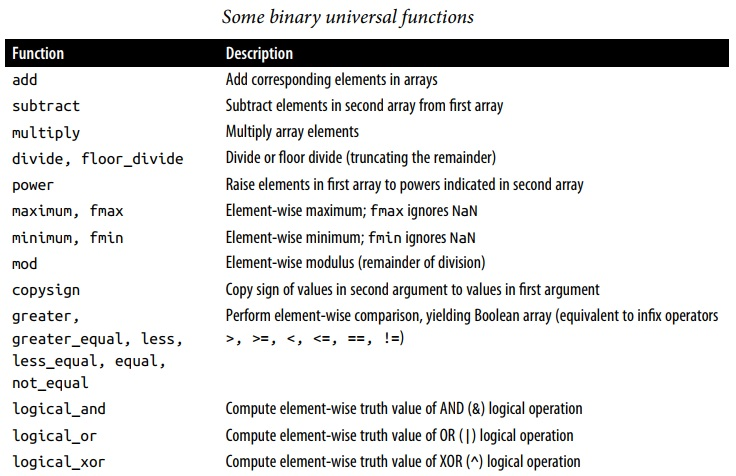

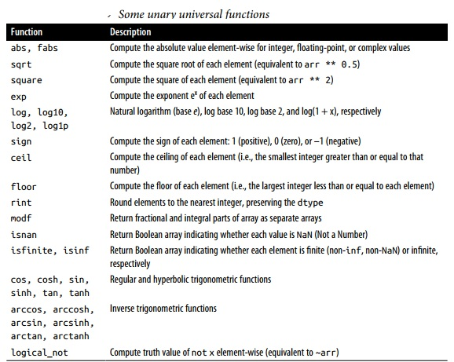

```python
np.add(non,2)
```

```
array([[2., 2., 2., 2., 2.],
       [3., 3., 3., 3., 3.],
       [4., 4., 4., 4., 4.],
       [5., 5., 5., 5., 5.]])
```

```python
non
```

```
array([[0., 0., 0., 0., 0.],
       [1., 1., 1., 1., 1.],
       [2., 2., 2., 2., 2.],
       [3., 3., 3., 3., 3.]])
```

np.where(non>0,1,-1)

```python
np.where(non==1,0,1)
```

```
array([[1, 1, 1, 1, 1],
       [0, 0, 0, 0, 0],
       [1, 1, 1, 1, 1],
       [1, 1, 1, 1, 1]])
```

### Given a list [1,2,3,4,5,6,7], find the numbers which are greater than 4.

```python
a=np.array([1,2,3,4,5,6,7])
b=np.where(a>4)
a[b]
```

```
array([5, 6, 7])
```

#### Given a list [1,1,0,0,1,0,1,0,1,1], count the number of 1's.

```python
a=np.array([1,1,0,0,1,0,1,0,1,1])
b=np.where(a==1)
len(b[0])
```

```
6
```

### Mathematical and Statistical Methods

A set of mathematical functions that compute statistics about an entire array or about the data along an axis are accessible as methods of the array class.

You can use aggregations (sometimes called reductions) like sum, mean, and std (standard deviation) either by calling the array instance method or using the top-level NumPy function.

When you use the NumPy function, like numpy.sum, you have to pass the array you want to aggregate as the first argument.

```python
arr
```

```
array([[ 0,  1,  2,  3],
       [ 0,  5,  6,  7],
       [ 8,  9,  0, 11],
       [12, 13, 14, 15],
       [16, 17, 18, 19],
       [20, 21, 22,  0],
       [24, 25, 26, 27],
       [28,  0, 30, 31]])
```

```python
arr.mean()
```

```
13.4375
```

```python
np.mean(arr)
```

```
13.4375
```

```python
arr
```

```
array([[ 0,  1,  2,  3],
       [ 0,  5,  6,  7],
       [ 8,  9,  0, 11],
       [12, 13, 14, 15],
       [16, 17, 18, 19],
       [20, 21, 22,  0],
       [24, 25, 26, 27],
       [28,  0, 30, 31]])
```

```python
arr.mean(axis=0) #compute sum down the rows
```

```
array([13.5  , 11.375, 14.75 , 14.125])
```

```python
arr.mean(axis=1) #compute mean across the columns
```

```
array([ 1.5 ,  4.5 ,  7.  , 13.5 , 17.5 , 15.75, 25.5 , 22.25])
```

```python
arr
```

```
array([[ 0,  1,  2,  3],
       [ 0,  5,  6,  7],
       [ 8,  9,  0, 11],
       [12, 13, 14, 15],
       [16, 17, 18, 19],
       [20, 21, 22,  0],
       [24, 25, 26, 27],
       [28,  0, 30, 31]])
```

```python
arr.cumsum()
```

```
array([  0,   1,   3,   6,   6,  11,  17,  24,  32,  41,  41,  52,  64,
        77,  91, 106, 122, 139, 157, 176, 196, 217, 239, 239, 263, 288,
       314, 341, 369, 369, 399, 430])
```

```python
arr
```

```
array([[ 0,  1,  2,  3],
       [ 0,  5,  6,  7],
       [ 8,  9,  0, 11],
       [12, 13, 14, 15],
       [16, 17, 18, 19],
       [20, 21, 22,  0],
       [24, 25, 26, 27],
       [28,  0, 30, 31]])
```

```python
arr.cumsum(axis=0)
```

```
array([[  0,   1,   2,   3],
       [  0,   6,   8,  10],
       [  8,  15,   8,  21],
       [ 20,  28,  22,  36],
       [ 36,  45,  40,  55],
       [ 56,  66,  62,  55],
       [ 80,  91,  88,  82],
       [108,  91, 118, 113]])
```

```python
arr.cumsum(axis=1)
```

```
array([[  0,   1,   3,   6],
       [  0,   5,  11,  18],
       [  8,  17,  17,  28],
       [ 12,  25,  39,  54],
       [ 16,  33,  51,  70],
       [ 20,  41,  63,  63],
       [ 24,  49,  75, 102],
       [ 28,  28,  58,  89]])
```

```python
arr.sort()
arr
```

```
array([[ 0,  1,  2,  3],
       [ 0,  5,  6,  7],
       [ 0,  8,  9, 11],
       [12, 13, 14, 15],
       [16, 17, 18, 19],
       [ 0, 20, 21, 22],
       [24, 25, 26, 27],
       [ 0, 28, 30, 31]])
```

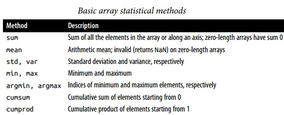

### Splitting array

```python
a=np.arange(12)
a
```

```
array([ 0,  1,  2,  3,  4,  5,  6,  7,  8,  9, 10, 11])
```

```python
np.hsplit(a,3) #np.split(a,3)
```

```
[array([0, 1, 2, 3]), array([4, 5, 6, 7]), array([ 8,  9, 10, 11])]
```

```python
np.hsplit(a,(2,4))
```

```
[array([0, 1]), array([2, 3]), array([ 4,  5,  6,  7,  8,  9, 10, 11])]
```

```python
import numpy as np
b=np.array([[1,2,3,4],[4,5,6,7],[7,8,9,0],[1,1,1,1]])
np.hsplit(b,2)
```

```
[array([[1, 2],
        [4, 5],
        [7, 8],
        [1, 1]]),
 array([[3, 4],
        [6, 7],
        [9, 0],
        [1, 1]])]
```

```python
import numpy as np
b=np.array([[1,2,3,4],[4,5,6,7],[7,8,9,0],[1,1,1,1]])
np.vsplit(b,2)
```

```
[array([[1, 2, 3, 4],
        [4, 5, 6, 7]]),
 array([[7, 8, 9, 0],
        [1, 1, 1, 1]])]
```

### File Input and Output with Arrays

NumPy is able to save and load data to and from disk in some text or binary formats.

**numpy.save** and **numpy.load** are the two workhorse functions for efficiently saving and loading array data on disk.

Arrays are saved by default in an uncompressed raw binary format with file extension .npy:

```python
arr = np.arange(10)
arr
```

```
array([0, 1, 2, 3, 4, 5, 6, 7, 8, 9])
```

```python
np.save("some_array", arr) #If the file path does not already end in .npy, the extension will be appended.
```

```python
np.load("some_array.npy")
```

```
array([0, 1, 2, 3, 4, 5, 6, 7, 8, 9])
```

## Sorting, Searching and Counting

### Sorting

In Numpy, we can perform various sorting operations using the various functions:

1. sort()
2. argsort
3. lexsort()

```python
arr=np.array([21,2,11,22,5,4,1,7,8])
arr.sort()
arr
```

```
array([ 1,  2,  4,  5,  7,  8, 11, 21, 22])
```

```python
arr=np.array([[21,2,11],[22,5,4],[1,7,8]])
arr.sort()
arr
```

```
array([[ 2, 11, 21],
       [ 4,  5, 22],
       [ 1,  7,  8]])
```

```python
arr=np.array([[21,2,11],[22,5,4],[1,7,8]])
arr.sort()
arr
```

```
array([[ 2, 11, 21],
       [ 4,  5, 22],
       [ 1,  7,  8]])
```

### numpy.sort()

By default, numpy does sorting in ascending order.

In 2-D array, sorting can be done along either of the axes i.e., row-wise or column-wise.

By default, sorting is done row-wise (i.e., on axis = 1). It means to arrange elements in each row in ascending order.

When axis=0, sorting is done column-wise, which means each column is sorted in ascending order.

```python
arr=np.array([21,2,11,22,5,4,1,7,8])
b=arr.argsort()
b
```

```
array([6, 1, 5, 4, 7, 8, 2, 0, 3], dtype=int64)
```

```python
arr=np.array([[21,2,11],[22,5,4],[1,7,8]])
b=arr.argsort()
b
```

```
array([[1, 2, 0],
       [2, 1, 0],
       [0, 1, 2]], dtype=int64)
```

### numpy.argsort

numpy.argsort(a, axis=-1, kind=None, order=None, *, stable=None)

It performs an indirect sort along the given axis using the algorithm specified by the kind keyword.

It returns an array of indices of the same shape as a that index data along the given axis in sorted order.

### numpy.argsort

numpy.argsort(a, axis=-1, kind=None, order=None, *, stable=None)

**Parameters:**

a:Array to sort.

axis: int or None, optional  
Axis along which to sort. The default is -1 (the last axis). If None, the flattened array is used.

kind: {‘quicksort’, ‘mergesort’, ‘heapsort’, ‘stable’}, optional  
Sorting algorithm. The default is ‘quicksort’.

order: str or list of str, optional  
When a is an array with fields defined, this argument specifies which fields to compare first, second, etc.

stable: bool, optional  
Sort stability. If True, the returned array will maintain the relative order of a values which compare as equal.  
If False or None, this is not guaranteed. Internally, this option selects kind='stable'. Default: None.

```python
fname=['ram','hari','sudha','ram']
lname=['sharma','pandey','kc','shrestha']
s=np.lexsort((lname,fname))
s
```

```
array([1, 0, 3, 2], dtype=int64)
```

```python
a=[1,2,1,2,2,3,1]
b=[3,2,3,2,1,4,1]
s=np.lexsort((a,b))
s
```

```
array([6, 4, 1, 3, 0, 2, 5], dtype=int64)
```

### numpy.lexsort()

Given multiple sorting keys, lexsort returns an array of integer indices that describes the sort order by multiple keys.

The last key in the sequence is used for the primary sort order, ties are broken by the second-to-last key, and so on.

### Searching

Searching is an operation or a technique that helps finds the place of a given element or value in the list.

Any search is said to be successful or unsuccessful depending upon whether the element that is being searched is found or not.

In Numpy, we can perform various searching operations using the various functions that are provided in the library like argmax, argmin, nanaargmax etc.

```python
arr=np.arange(10)
arr
```

```
array([0, 1, 2, 3, 4, 5, 6, 7, 8, 9])
```

```python
np.argmax(arr)
```

```
9
```

```python
arr=np.arange(12).reshape(4,3)
arr[1][1]=10
arr
```

```
array([[ 0,  1,  2],
       [ 3, 10,  5],
       [ 6,  7,  8],
       [ 9, 10, 11]])
```

```python
np.argmax(arr,axis=0)
```

```
array([3, 1, 3], dtype=int64)
```

```python
np.argmax(arr,axis=1)
```

```
array([2, 1, 2, 2], dtype=int64)
```

### What will you do if you need to find the max item and its index from second row?

```python
np.max(arr[1])
```

```
10
```

```python
np.argmax(arr[1])
```

```
1
```

```python
b=np.argmin(arr,axis=0)
b
```

```
array([0, 0, 0], dtype=int64)
```

```python
b=np.argmin(arr,axis=1)
b
```

```
array([0, 0, 0, 0], dtype=int64)
```

```python
arr
```

```
array([[ 0,  1,  2],
       [ 3, 10,  5],
       [ 6,  7,  8],
       [ 9, 10, 11]])
```

```python
b=np.where(arr<2)
b
```

```
(array([0, 0], dtype=int64), array([0, 1], dtype=int64))
```

```python
arr[b]
```

```
array([0, 1])
```

### Given an array find the number of items greater than 4 and also display them:

[1,2,3,4,5,6,1,3,4]

```python
a=np.array([1,2,3,4,5,6,1,3,4])
b=np.where(a>4)
print("Numbers greater than 4 is {0} and count is {1}".format(a[b],len(b[0])))
```

```
Numbers greater than 4 is [5 6] and count is 2
```

### Counting

```python
arr=np.array([0,1,2,0,4,5,0])
np.size(arr)
```

```
7
```

```python
arr=np.array([0,1,2,0,4,5,0])
np.count_nonzero(arr)
```

```
4
```

### Find the number of zeros in array arr

```python
np.size(arr)-np.count_nonzero(arr)
```

```
3
```

```python
n=np.where(arr==0)
np.size(n)
```

```
3
```

### To display the matrix with 1 in border

```python
x=np.ones([10,10])
x[1:9,1:9]=0
x
```

```
array([[1., 1., 1., 1., 1., 1., 1., 1., 1., 1.],
       [1., 0., 0., 0., 0., 0., 0., 0., 0., 1.],
       [1., 0., 0., 0., 0., 0., 0., 0., 0., 1.],
       [1., 0., 0., 0., 0., 0., 0., 0., 0., 1.],
       [1., 0., 0., 0., 0., 0., 0., 0., 0., 1.],
       [1., 0., 0., 0., 0., 0., 0., 0., 0., 1.],
       [1., 0., 0., 0., 0., 0., 0., 0., 0., 1.],
       [1., 0., 0., 0., 0., 0., 0., 0., 0., 1.],
       [1., 0., 0., 0., 0., 0., 0., 0., 0., 1.],
       [1., 1., 1., 1., 1., 1., 1., 1., 1., 1.]])
```

### Difference between list and array of numpy:

```python
L=[3,4,5]
N=np.array([3,4,5])
```

```python
L*3
```

```
[3, 4, 5, 3, 4, 5, 3, 4, 5]
```

```python
N*3
```

```
array([ 9, 12, 15])
```